# P&S-2024: Final Project

Viktor Pakholok (https://github.com/viktorpakholok) Lysyk Lev (https://github.com/Lius912) Bohdan Milian (https://github.com/Bohdanok)

# **The aim of the project:**

Analyze and visualize the dataset provided by the Steam game service to identify and explore potential correlations between various characteristics. Get some meaningful insights and present them.

## *For this we used the dataset from Kaggle*

https://www.kaggle.com/datasets/fronkongames/steam-games-dataset?resource=download

# **Data specifications:**

*This dataset provides detailed information about video games, including their titles, release dates, pricing, and supported platforms (Windows, Mac, Linux). It has user interaction metrics like peak concurrent users, reviews, and playtime data, along with additional details such as categories, genres, tags, and achievements. The dataset also captures commercial and content-related information like estimated owners, downloadable content (DLC) counts, and Metacritic (https://www.metacritic.com/) scores for popular games.*

```r
dataset <- read.csv("games_fixed_columns2.csv")
head(dataset, 7)
```

|  | X | Name | Release.date | Estimated.owners | Peak.CCU | Required.age | Price | DiscountDLC.count | About.the.game | Supported.languages | Full.audio.languages | Reviews | Windows | Mac | Linux | Metacritic.score | Positive | Negative | Score.rank | Achievements | Notes | Average.playtime.forever | Average.playtime.two.weeks | Median.playtime.forever | Categories | Genres | Tags |
| --- | --- | --- | --- | --- | --- | --- | --- | --- | --- | --- | --- | --- | --- | --- | --- | --- | --- | --- | --- | --- | --- | --- | --- | --- | --- | --- | --- |
| 1 | 0 | Galactic Bowling | Oct 21, 2008 | 0 - 20000 | 0 | 0 | 19.99 | 0 | Galactic Bowling is an exaggerated and stylized bowling game with an intergalactic twist. Players will engage in fast-paced single and multi-player competition while being submerged in a unique new un… | ['English'] | [] |  | True | False | False | 0 | 6 | 11 | NA | 30 |  | 0 | 0 | 0 | Single-player,Multi-player,Steam Achievements,Partial Controller Support | Casual,Indie,Sports | Indie,Casual,Sports,Bowling |
| 2 | 1 | Train Bandit | Oct 12, 2017 | 0 - 20000 | 0 | 0 | 0.99 | 0 | THE LAW!! Looks to be a showdown atop a train. This will be your last fight. Good luck, Train Bandit. WHAT IS THIS GAME? Train Bandit is a simple score attack game. The Law will attack you from both s… | ['English', 'French', 'Italian', 'German', 'Spanish - Spain', 'Japanese', 'Portuguese - Brazil', 'Russian', 'Simplified Chinese', 'Traditional Chinese'] | [] |  | True | True | False | 0 | 53 | 5 | NA | 12 |  | 0 | 0 | 0 | Single-player,Steam Achievements,Full controller support,Steam Leaderboards,Remote Play on Phone,Remote Play on Tablet,Remote Play on TV | Action,Indie | Indie,Action,Pixel Graphics,2D,Retro,Arcade,Score Attack,Minimalist,Comedy,Singleplayer,Fast-Paced,Casual,Funny,Parody,Difficult,Gore,Violent,Western,Controller,Blood |
| 3 | 2 | Jolt Project | Nov 17, 2021 | 0 - 20000 | 0 | 0 | 4.99 | 0 | Jolt Project: The army now has a new robotics project, jolt. It's up to you to control it and ensure the success of the missions! There are 9 stages of taking the breath away with the right difficulty… | ['English', 'Portuguese - Brazil'] | [] |  | True | False | False | 0 | 0 | 0 | NA | 0 |  | 0 | 0 | 0 | Single-player | Action,Adventure,Indie,Strategy |  |
| 4 | 3 | Henosis™ | Jul 23, 2020 | 0 - 20000 | 0 | 0 | 5.99 | 0 | HENOSIS™ is a mysterious 2D Platform Puzzler where players are propelled into weird and visceral worlds as they take control of a small, droplet of water while overcoming obstacles and enemies through… | ['English', 'French', 'Italian', 'German', 'Spanish - Spain', 'Japanese', 'Korean', 'Portuguese', 'Russian', 'Simplified Chinese', 'Traditional Chinese'] | [] |  | True | True | True | 0 | 3 | 0 | NA | 0 |  | 0 | 0 | 0 | Single-player,Full controller support | Adventure,Casual,Indie | 2D Platformer,Atmospheric,Surreal,Mystery,Puzzle,Survival,Adventure,Linear,Singleplayer,Experimental,Platformer,Precision Platformer,Puzzle-Platformer,2D,Stylized,Physics,Time Manipulation,Casual,Indi… |
| 5 | 4 | Two Weeks in Painland | Feb 3, 2020 | 0 - 20000 | 0 | 0 | 0.00 | 0 | ABOUT THE GAME Play as a hacker who has arranged a deal with a gangster. That’s how the protagonist, Jack, is assigned a mission that should be accomplished in a specific timeframe, which he will find… | ['English', 'Spanish - Spain'] | [] |  | True | True | False | 0 | 50 | 8 | NA | 17 | This Game may contain content not appropriate for all ages, or may not be appropriate for viewing at work: violence, general Mature Content. | 0 | 0 | 0 | Single-player,Steam Achievements | Adventure,Indie | Indie,Adventure,Nudity,Violent,Sexual Content,Story Rich |
| 6 | 5 | Wartune Reborn | Feb 26, 2021 | 50000 - 100000 | 68 | 0 | 0.00 | 0 | Feel tired of auto-fight? Feel tired of boring numerical combinations? Let us try this amazing and exciting game! Right! Wartune Reborn is the super popular magic epic game as we know. Now, the magnif… | ['English'] | [] |  | True | False | False | 0 | 87 | 49 | NA | 0 |  | 0 | 0 | 0 | Single-player,Multi-player,MMO,PvP,Online PvP,Co-op,Online Co-op,In-App Purchases | Adventure,Casual,Free to Play,Massively Multiplayer,RPG,Strategy | Turn-Based Combat,Massively Multiplayer,Multiplayer,RPG,Tactical RPG,Exploration,PvP,MMORPG,Turn-Based Strategy,God Game,Strategy,2.5D,Magic,Medieval,Mythology,Class-Based,Turn-Based Tactics,Singlepla… |
| 7 | 6 | TD Worlds | Jan 9, 2022 | 0 - 20000 | 3 | 0 | 10.99 | 1 | TD Worlds is a dynamic, highly strategical game that challenges your skill. Build an impenetrable defense and get ready to plunge into a new, unknown world to uncover its secrets. In this bizarre univ… | ['English', 'Russian', 'Danish'] | [] |  | True | False | False | 0 | 21 | 7 | NA | 62 |  | 0 | 0 | 0 | Single-player,Steam Achievements,Steam Cloud | Indie,Strategy | Tower Defense,Rogue-lite,RTS,Replay Value,Perma Death,2D,Isometric,Difficult,Rogue-like,Dynamic Narration,Stylized,Real Time Tactics,Strategy,Minimalist,Abstract,Tactical,Atmospheric,Singleplayer,Sci-… |

($H_0$): The prices in the dataset follow an exponential distribution with rate parameter $\lambda = \frac{1}{\text{mean_price}}$.
$$H_0: F(x) = 1 - e^{-\lambda x}, \quad \text{for } x \geq 0$$

($H_1$): The prices in the dataset do not follow an exponential distribution with rate parameter $\lambda = \frac{1}{\text{mean_price}}$.
$$H_1: F(x) \neq 1 - e^{-\lambda x}, \quad \text{for } x \geq 0$$

```r
mean_price <- mean(dataset$Price, na.rm = TRUE)
lambda <- 1 / mean_price

breaks <- c(seq(0, 49.5, by = 1), Inf)
hist_obj <- hist(dataset$Price,
                 breaks = breaks,
                 main = "Price Distribution with Exponential Fit",
                 xlab = "Price Ranges",
                 ylab = "Count of Prices",
                 col = "skyblue",
                 border = "blue",
                 freq = FALSE,
                 xlim = c(0, 51))

curve(dexp(x, rate = lambda), col = "red", lwd = 2, add = TRUE)

ks_test <- ks.test(dataset$Price, "pexp", rate = lambda)
print(ks_test)
```

```
##
##  Asymptotic one-sample Kolmogorov-Smirnov test
##
## data:  dataset$Price
## D = 0.20245, p-value < 2.2e-16
## alternative hypothesis: two-sided
```

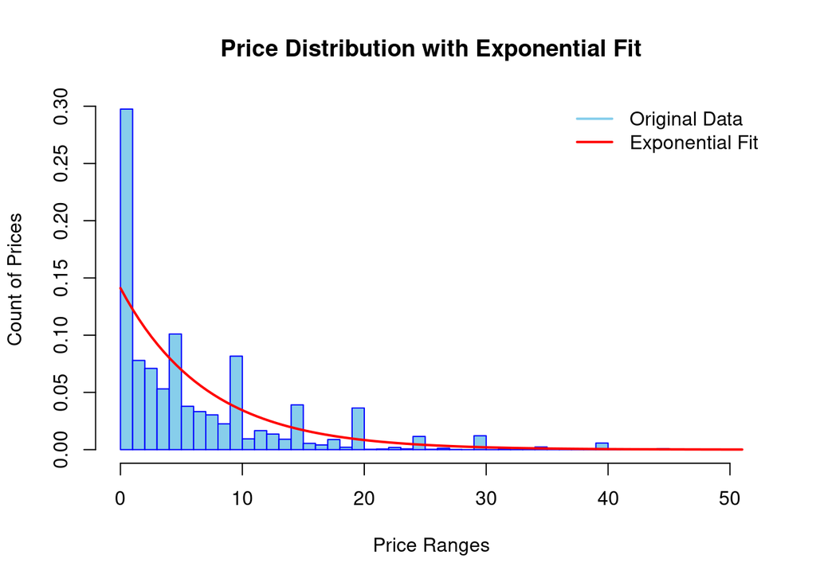

```r
legend("topright", legend = c("Original Data", "Exponential Fit"),
       col = c("skyblue", "red"),
       lwd = 2,
       bty = "n")
```

We reject $H_0$ in favor of the alternative hypothesis $H_1$. This tells us that the price distribution does not follow an exponential distribution and we cannot tell, which distribution it is.

Now we will try to plot the distribution of scores, that users gave to the games. Since our dataset provides the count of positive and negative scores, we will try to normalize them in the way:
$$Score = \frac{Positive + 1}{\text{Positive +
Negative + 2}}$$
to plot them in a compatible way.

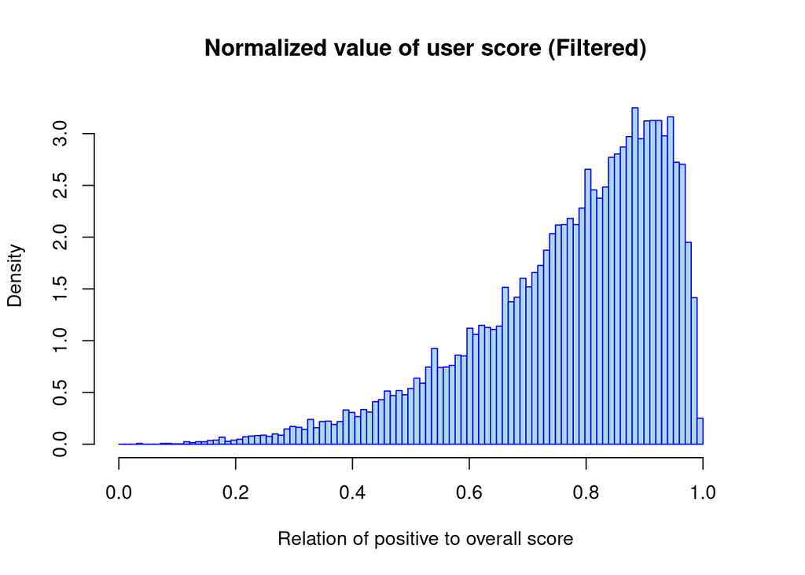

```r
sum_values <- dataset$Positive + dataset$Negative
difference <- ifelse(sum_values > 45, (dataset$Positive + 1) / (dataset$Negative + dataset$Positive + 2),NA)

difference <- difference[!is.na(difference)]

breaks <- seq(floor(min(difference)), ceiling(max(difference)), length.out = 100)

hist(
  difference,
  breaks = breaks,
  main = "Normalized value of user score (Filtered)",
  xlab = "Relation of positive to overall score",
  col = "lightblue",
  border = "blue",
  freq = FALSE,
  xlim = range(0, 1.05)
)
```

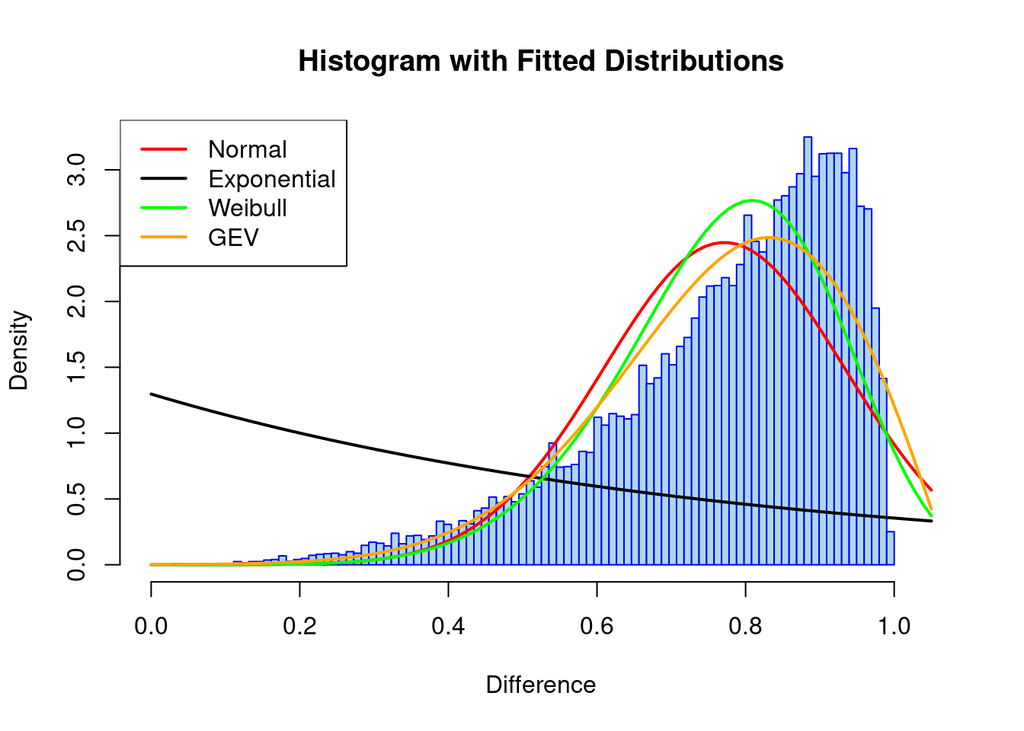

```r
fit_normal <- fitdistr(difference, "normal")

fit_exponential <- fitdistr(difference, "exponential")

fit_weibull <- fitdistr(difference, "weibull")


fit_genextreme <- vglm(difference ~ 1, gev, trace = FALSE)

hist(
  difference,
  breaks = breaks,
  freq = FALSE,
  xlim = range(0, 1.05),
  main = "Histogram with Fitted Distributions",
  xlab = "Difference",
  col = "lightblue",
  border = "blue"
)

curve(dnorm(x, mean = fit_normal$estimate["mean"], sd = fit_normal$estimate["sd"]), col = "red", lwd = 2, add = TRUE)

curve(dexp(x, rate = fit_exponential$estimate["rate"]), col = "black", lwd = 2, add = TRUE)

curve(dweibull(x, shape = fit_weibull$estimate["shape"], scale = fit_weibull$estimate["scale"]), col = "green", lwd = 2, add = TRUE)

curve(dgev(x, loc = Coef(fit_genextreme)["location"], scale = Coef(fit_genextreme)["scale"], shape = Coef(fit_genextreme)["shape"]), col = "orange", lwd = 2, add = TRUE)


legend(
  "topleft",
  legend = c("Normal", "Exponential", "Weibull", "GEV"),
  col = c("red", "black", "green", "orange"),
  lwd = 2
)
```

```r
empirical <- ecdf(difference)

# Normal distribution
ks_normal <- ks.test(
  difference,
  "pnorm",
  mean = fit_normal$estimate["mean"],
  sd = fit_normal$estimate["sd"]
)

# Exponential distribution
ks_exponential <- ks.test(
  difference,
  "pexp",
  rate = fit_exponential$estimate["rate"]
)

# Weibull distribution
ks_weibull <- ks.test(
  difference,
  "pweibull",
  shape = fit_weibull$estimate["shape"],
  scale = fit_weibull$estimate["scale"]
)

# Generalized Extreme Value (GEV) distribution
ks_genextreme <- ks.test(
  difference,
  "pgev",
  loc = Coef(fit_genextreme)["location"],
  scale = Coef(fit_genextreme)["scale"],
  shape = Coef(fit_genextreme)["shape"]
)

p_values <- c(
  normal = ks_normal$p.value,
  exponential = ks_exponential$p.value,
  weibull = ks_weibull$p.value,
  genextreme = ks_genextreme$p.value
)

best_fit <- names(which.max(p_values))
largest_p_value <- max(p_values)

print("P-values for each distribution:")
```

```
## [1] "P-values for each distribution:"
```

```r
print(p_values)
```

```
##        normal   exponential       weibull    genextreme
## 3.613465e-187  0.000000e+00 1.599855e-120  6.467115e-75
```

```r
cat("Distribution with the largest p-value:", best_fit, "\n")
```

```
## Distribution with the largest p-value: genextreme
```

```r
cat("Largest p-value:", largest_p_value, "\n")
```

```
## Largest p-value: 6.467115e-75
```

The closest distribution is genextreme (https://en.wikipedia.org/wiki/Generalized_extreme_value_distribution). But we can not say that this is the distribution of our distribution of scores, because of small $p-value$.

Here we’ll see the heatmap to show relationships between variables in a dataset

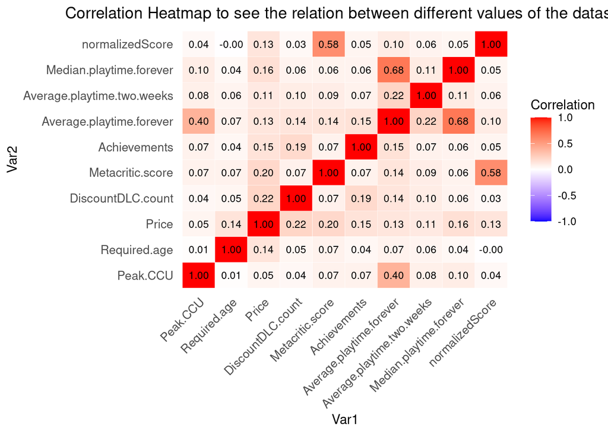

```r
dataset$normalizedScore <- ((dataset$Positive + 1) / (dataset$Negative + dataset$Positive + 2))

filtered_dataset <- dataset[dataset$Metacritic.score > 0, ]

correlation_matrix <- cor(filtered_dataset[sapply(filtered_dataset, is.numeric) & names(filtered_dataset) != "Score.rank" & names(filtered_dataset) != "Positive" & names(filtered_dataset) != "Negative" &names(filtered_dataset) != "X"])


ggplot(data = melt(correlation_matrix), aes(x = Var1, y = Var2, fill = value)) +
  geom_tile(color = "white") +

  geom_text(aes(label = sprintf("%.2f", value)), color = "black", size = 3) +

  scale_fill_gradient2(low = "blue", high = "red", mid = "white", midpoint = 0,
                       limit = c(-1, 1), space = "Lab", name = "Correlation") +
  theme_minimal() +
  theme(
    axis.text.x = element_text(angle = 45, hjust = 1, size = 10),
    axis.text.y = element_text(size = 10),
    panel.grid.major = element_blank(),
    panel.grid.minor = element_blank()
  ) +
  ggtitle("Correlation Heatmap to see the relation between different values of the dataset") +
  theme(plot.title = element_text(hjust = 0.5))
```

From this heatmap we can see, that the correlation between the Metacritic score and user score is considerable, although not very high. This is because the point of view of professionals not always aligns with the masses.